# The Case of the Missing Offense

January 29, 2017

## Introduction

## Introduction

### Why does it matter?

Baseball is a game flooded with statistics, and through the mountain of data it can be easy to forget what matters.

- Irrelevant statistics
- Paul DePodesta
- Short term vs. long term

## Introduction

### The goal

- Initial goal
- Peripheral findings: league-wide trends
- The combination of the two

## The Dataset

## The Dataset

### Source

[Sean Lahman's Baseball Database](http://www.seanlahman.com/baseball-archive/statistics/)

- Pitching, Hitting, Fielding
- Team-wide, player-specific
- Regular season, playoffs
- 1871 to 2015

I used **Teams.csv** from 2005 to 2015

## The Dataset

### Source preview

*Preview of columns from a sample of the data*:

| Year | Team | Games | Wins | Losses | Runs | Hits | Homeruns | Walks | Strikeouts | ERA |
| --- | --- | --- | --- | --- | --- | --- | --- | --- | --- | --- |
| 2005 | BOS | 162 | 95 | 67 | 910 | 1579 | 199 | 653 | 1044 | 4.74 |
| 2008 | DET | 162 | 74 | 88 | 821 | 1529 | 200 | 572 | 1076 | 4.9 |
| 2010 | COL | 162 | 83 | 79 | 770 | 1452 | 173 | 585 | 1274 | 4.14 |
| 2013 | NYY | 162 | 85 | 77 | 650 | 1321 | 144 | 466 | 1214 | 3.94 |
| 2015 | FLA | 162 | 71 | 91 | 613 | 1420 | 120 | 375 | 1150 | 4.02 |

## The Dataset

### Columns I added

#### Columns added to dataset

*Going forward, I will refer to this data as the master data*:

| Year | Team | BA | OBP | Win Ratio | Made Playoffs | Group |
| --- | --- | --- | --- | --- | --- | --- |
| 2005 | BOS | 0.281 | 0.357 | 0.586 | Yes | 1 |
| 2008 | DET | 0.271 | 0.34 | 0.457 | No | 3 |
| 2010 | COL | 0.263 | 0.336 | 0.512 | No | 2 |
| 2013 | NYY | 0.242 | 0.307 | 0.525 | No | 2 |
| 2015 | FLA | 0.26 | 0.31 | 0.438 | No | 3 |

## Results

## Results

### Mean difference explanation

A key statistic I used to compare playoff and non-playoff teams is the mean of their differences of each year for a given variable.

| Year | MadePlayoffs | Runs |
| --- | --- | --- |
| 2005 | No | 730.7 |
| 2005 | Yes | 781.1 |
| 2006 | No | 777.7 |
| 2006 | Yes | 811.2 |
| 2007 | No | 756.3 |
| 2007 | Yes | 835.5 |

## Results

### Mean difference explanation

*The differences of means (playoff minus non-playoff) from the previous table*

| 2005 | 2006 | 2007 |
| --- | --- | --- |
| 50.4 | 33.6 | 79.2 |

## Results

### Mean difference explanation

*The mean of the differences of Runs Scored from 2005-2015*

```
## [1] 69.33802
```

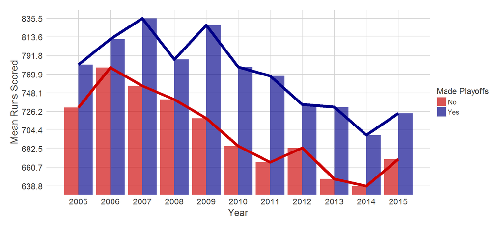

## Results

### Playoff vs. non-playoff

Similarly to **Runs Scored**, **Hits** and **Walks** topped the batting statistics, while **Hits Allowed** and **Walks Allowed** topped the pitching statistics favoring playoff teams.

Okay, but this is expected, right? Shouldn't the teams that can score more runs and get more hits win? Not so fast!

## Results

### Correlation of playoff team batting variables

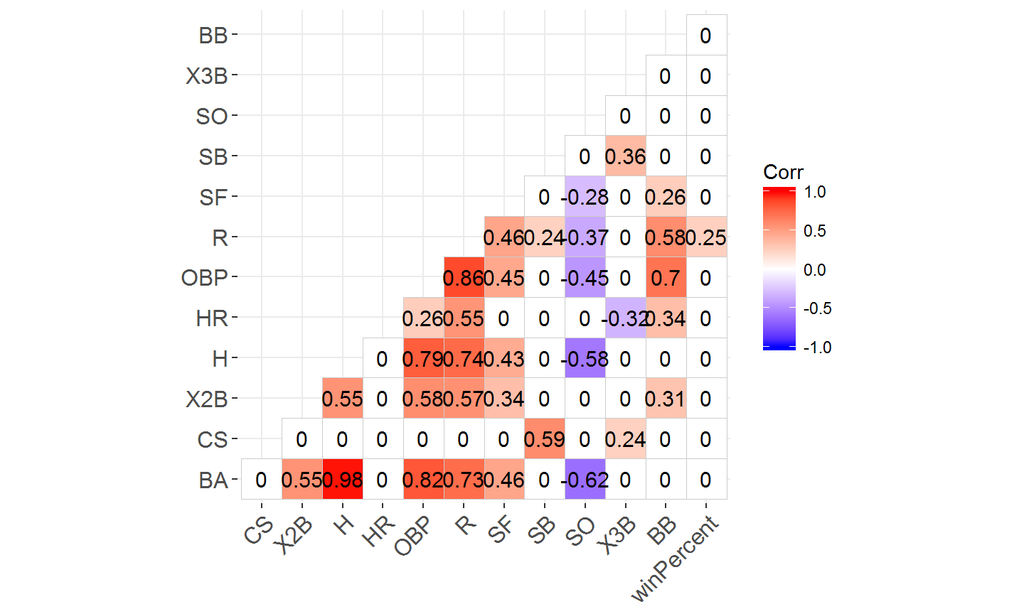

## Results

### Correlation of non-playoff team batting variables

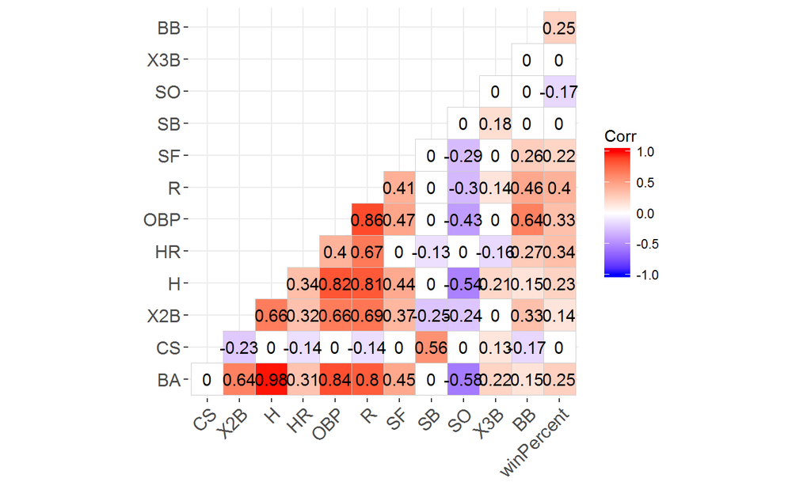

## Results

### Correlation

- Runs (R) to Win Percent: Playoff teams have a weak positive correlation of Runs to Win Percent (0.25), while non-playoff teams have a moderate positive correlation (.40). We have seen previously that Playoff teams are scoring more runs overall. The low correlation of Runs to Win Percent could potentially be a sign that it's not the number of runs but the efficiency of Runs that sets playoff teams apart.
- Home runs (HR) to Runs and Walks (BB) to Runs: Playoff teams have a moderate positive correlation of HR to Runs (0.55), while non-playoff teams of a strong positive correlation (0.67). The reverse is true of Walks to Runs. Playoff teams are Walking more and hitting more Home Runs as seen previously but potentially are spreading out their sources of runs more effectively. This is relevant so that if a few of their players go cold, others can pick them up.

## Results

### League-wide trends

The league-wide trends in the MLB caught my eye more than the differences between teams of varying playoff status.

I saw that runs and hits were down, so I thought "Okay, it probably has a lot to do with the performance enhancing drug crackdown":

## Results

### League-wide trends: Runs

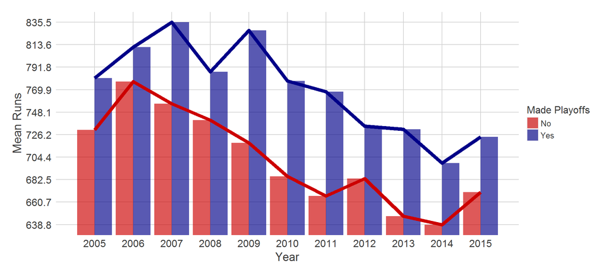

## Results

### League-wide trends: Hits

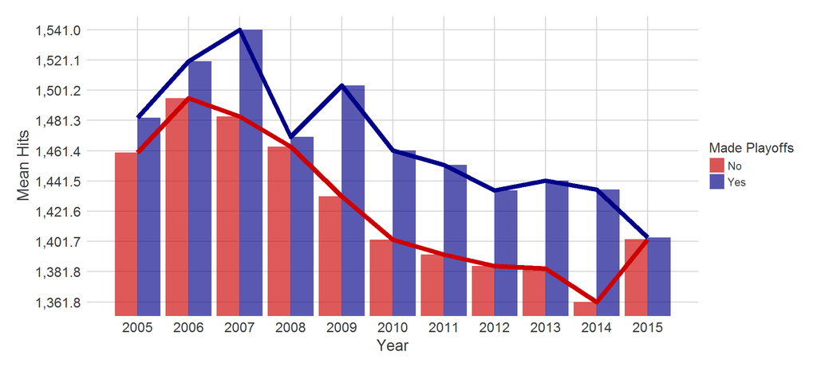

## Results

### League-wide trends

Then, I saw the strikeouts and walks numbers…

## Results

### League-wide trends: Strikeouts

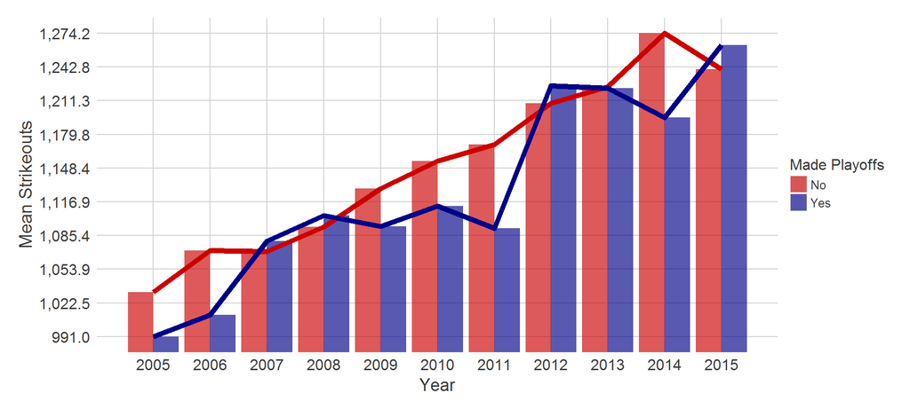

## Results

### League-wide trends: Walks

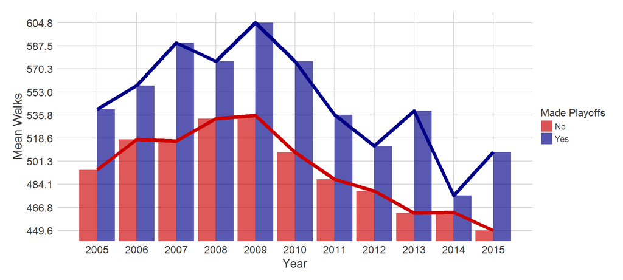

## Results

### League-wide trends

When hits, runs, and walks are down, and strikeouts are up, you cannot blame drug-testing, large, pitcher-friendly stadiums, or other external factors. Either the hitters are getting worse, or *the pitchers are getting better*. I must explore further, but it seems logical to say that if hitters' numbers are low league-wide for numbers that aren't improved by external factors but rather by natural ability, then it's plausible that pitchers are just doing a better job at adjusting to hitters than the reverse.

- The shift
- Hitter weak zones

## Conclusion

## Conclusion

### Closing remarks

Especially at a time in baseball when the offensive numbers are down and the defensive side has the upper hand, every scoring opportunity must be taken and sources of runs must be varied. Every opportunity missed is another potential loss, and the opportunities are only getting fewer. The teams who make the playoffs are best at this. However, efficiency and varied source of runs might not be the only solution. The defense has adjusted; can the offense adjust back?

## Conclusion

### Next steps

While I could make some remarks by eyeballing plots, data science is more than that. Upon further reading and given more time, I would

- run significance tests to compare the difference in mean differences and variable correlations
- further divide the playoff and non-playoff teams. I would check the bottom 3-5 playoffs teams against the top 3-5 non-playoff teams
- do a deeper player-level analysis to see what I can uncover